# MSDS 430 Milestone 2

#### Complete the following step by step instructions and submit your notebook and data file to Canvas. Your completed notebook should include all output, i.e. run each cell and save your file before submitting.

In this second milestone we will continue working toward the final project for this course. By now you should have a very clear picture of your plans for the final project, so these steps will simply walk you through some of the work.

Step 1 (5 pts.): In Milestone 1, you gave a brief summary of your overall plans for the final project. What has changed since then? Has your problem changed? Did you choose a different data set? Why or why not? What additional detail can you provide with regard to your goals for the final project?

For my project the problem has stayed the same, but I have eleiminated a few steps. I will no longer be calculating the following:

- The average amount of rounds each fighter fights and who, on average, fights the most rounds.
- The average round a fighter loses in, and the average round a fighter wins in.
- the amount of strikes or grappling attempted and not landed had any correlation to loss

I do not think these have any bearing on the simple prediction of who will win or lose. I planning on comparing a simple point sumation to determine who the winner might be in each case, based on the other calculations I will be doing, and I don't see how I can award points for these things.

Step 2 (5 pts.): Read in your data file and use pandas and clean up your data as needed. Extract only what you will be using for this project and demonstrate this by creating a nicely formatted table of the first 20 rows of data relevant to your needs for the project. Each column should align nicely and be clearly labeled. Remember to include any relevant comments within your code.

```python
import pandas as pd
# Import original data into pandas from csv
ufc_data = pd.read_csv("UFC_Rounds.csv")
# List of known named columns that must be dropped. Some fight round columns will be dropped later
columns_to_drop = ['Date', 'Event_ID', 'Last_round', 'Max_round', 'RStreak', 'HomeTown', 'Location', 'Weight']
# Drop afformentioned columns
ufc_data = ufc_data.drop(columns=columns_to_drop)

# Now we have many columns of round data. The only columns that we want to keep are either strikes landed or submissions
# landed. Which means we have to drop every column that doesn't have a label which matches this pattern:
# 'Round * _Landed'
for i in ufc_data.columns.values:
    # Check if this is a Round columnn:
    if i.startswith('Round'):
        # If the column describes a landed technique, keep it. Otherwise drop it
        if i.endswith('Landed'):
            pass

        else:
            ufc_data = ufc_data.drop(i, axis=1)

# To simplyfy the data set further, I'm only keeping the 'Round N Total Strikes Landed' columns
for i in ufc_data.columns.values:
    # Check if this is a strikes column
    if 'Strikes' in i:
        # If this is the total strikes landed column, keep it. Otherwise drop it
        if i.endswith('_Strikes_Total Strikes_Landed'):
            pass

        else:
            ufc_data = ufc_data.drop(i, axis=1)

# Since I'm also comparing wins and losses, I will have to remove the 'draw' and 'no contest' fights to simplify things
for index, row in ufc_data.iterrows():
    # Check if fight is a draw or no contest, if so remove the record
    if row.loc['winner'] == 'draw' or row.loc['winner'] == 'no contest':
        ufc_data = ufc_data.drop(index)

# There are still 30 columns, which is signifigantly less than before, but hard to see in jupyter.
# So for information purposes I will also print the columns
print(ufc_data.columns.values)

ufc_data.head(20)
```

```
['Id' 'Fight_ID' 'winby' 'winner' 'corner' 'Prev' 'Age' 'Height' 'ID'
 'Name' 'Round1_Grappling_Reversals_Landed'
 'Round1_Grappling_Standups_Landed' 'Round1_Grappling_Takedowns_Landed'
 'Round1_Strikes_Total Strikes_Landed' 'Round2_Grappling_Reversals_Landed'
 'Round2_Grappling_Standups_Landed' 'Round2_Grappling_Takedowns_Landed'
 'Round2_Strikes_Total Strikes_Landed' 'Round3_Grappling_Reversals_Landed'
 'Round3_Grappling_Standups_Landed' 'Round3_Grappling_Takedowns_Landed'
 'Round3_Strikes_Total Strikes_Landed' 'Round4_Grappling_Reversals_Landed'
 'Round4_Grappling_Standups_Landed' 'Round4_Grappling_Takedowns_Landed'
 'Round4_Strikes_Total Strikes_Landed' 'Round5_Grappling_Reversals_Landed'
 'Round5_Grappling_Standups_Landed' 'Round5_Grappling_Takedowns_Landed'
 'Round5_Strikes_Total Strikes_Landed']
```

|  | Id | Fight_ID | winby | winner | corner | Prev | Age | Height | ID | Name | ... | Round3_Grappling_Takedowns_Landed | Round3_Strikes_Total Strikes_Landed | Round4_Grappling_Reversals_Landed | Round4_Grappling_Standups_Landed | Round4_Grappling_Takedowns_Landed | Round4_Strikes_Total Strikes_Landed | Round5_Grappling_Reversals_Landed | Round5_Grappling_Standups_Landed | Round5_Grappling_Takedowns_Landed | Round5_Strikes_Total Strikes_Landed |
| --- | --- | --- | --- | --- | --- | --- | --- | --- | --- | --- | --- | --- | --- | --- | --- | --- | --- | --- | --- | --- | --- |
| 0 | 0 | 6627 | DEC | blue | blue | 1 | 25.0 | 172.0 | 2809 | Ketlen Vieira | ... | 0.0 | 0.0 | 0.0 | 0.0 | 0.0 | 0.0 | 0.0 | 0.0 | 0.0 | 0.0 |
| 1 | 1 | 6545 | DEC | blue | blue | 1 | 30.0 | 170.0 | 1970 | Tim Elliott | ... | 0.0 | 0.0 | 0.0 | 0.0 | 0.0 | 0.0 | 0.0 | 0.0 | 0.0 | 0.0 |
| 2 | 2 | 6547 | KO/TKO | red | blue | 2 | 28.0 | 185.0 | 2789 | Andrew Sanchez | ... | 0.0 | 0.0 | 0.0 | 0.0 | 0.0 | 0.0 | 0.0 | 0.0 | 0.0 | 0.0 |
| 3 | 3 | 6589 | DEC | blue | blue | 2 | 27.0 | 180.0 | 2375 | Renato Moicano | ... | 0.0 | 0.0 | 0.0 | 0.0 | 0.0 | 0.0 | 0.0 | 0.0 | 0.0 | 0.0 |
| 4 | 4 | 6546 | DEC | red | blue | 3 | 28.0 | 190.0 | 2364 | Jake Collier | ... | 0.0 | 0.0 | 0.0 | 0.0 | 0.0 | 0.0 | 0.0 | 0.0 | 0.0 | 0.0 |
| 5 | 5 | 6624 | KO/TKO | blue | blue | 0 | 23.0 | 170.0 | 2882 | Tom Duquesnoy | ... | 0.0 | 0.0 | 0.0 | 0.0 | 0.0 | 0.0 | 0.0 | 0.0 | 0.0 | 0.0 |
| 6 | 6 | 6591 | KO/TKO | blue | red | 6 | 37.0 | 185.0 | 896 | Jacare Souza | ... | 0.0 | 0.0 | 0.0 | 0.0 | 0.0 | 0.0 | 0.0 | 0.0 | 0.0 | 0.0 |
| 7 | 7 | 6625 | DEC | blue | red | 3 | 30.0 | 177.0 | 1683 | Bobby Green | ... | 0.0 | 0.0 | 0.0 | 0.0 | 0.0 | 0.0 | 0.0 | 0.0 | 0.0 | 0.0 |
| 8 | 8 | 6592 | SUB | red | red | 6 | 32.0 | 182.0 | 1422 | Zak Cummings | ... | 0.0 | 0.0 | 0.0 | 0.0 | 0.0 | 0.0 | 0.0 | 0.0 | 0.0 | 0.0 |
| 9 | 9 | 6545 | DEC | blue | red | 8 | 25.0 | 175.0 | 2166 | Louis Smolka | ... | 0.0 | 0.0 | 0.0 | 0.0 | 0.0 | 0.0 | 0.0 | 0.0 | 0.0 | 0.0 |
| 10 | 10 | 6592 | SUB | red | blue | 2 | 38.0 | 177.0 | 1296 | Nathan Coy | ... | 0.0 | 0.0 | 0.0 | 0.0 | 0.0 | 0.0 | 0.0 | 0.0 | 0.0 | 0.0 |
| 11 | 11 | 6602 | DEC | red | blue | 7 | 40.0 | 182.0 | 1015 | Roy Nelson | ... | 0.0 | 0.0 | 0.0 | 0.0 | 0.0 | 0.0 | 0.0 | 0.0 | 0.0 | 0.0 |
| 12 | 12 | 6624 | KO/TKO | blue | red | 2 | 35.0 | 172.0 | 2219 | Patrick Williams | ... | 0.0 | 0.0 | 0.0 | 0.0 | 0.0 | 0.0 | 0.0 | 0.0 | 0.0 | 0.0 |
| 13 | 13 | 6544 | SUB | red | red | 4 | 24.0 | 165.0 | 2344 | Rose Namajunas | ... | 0.0 | 0.0 | 0.0 | 0.0 | 0.0 | 0.0 | 0.0 | 0.0 | 0.0 | 0.0 |
| 14 | 14 | 6546 | DEC | red | red | 2 | 26.0 | 182.0 | 2780 | Devin Clark | ... | 0.0 | 0.0 | 0.0 | 0.0 | 0.0 | 0.0 | 0.0 | 0.0 | 0.0 | 0.0 |
| 15 | 15 | 6547 | KO/TKO | red | red | 2 | 28.0 | 193.0 | 1843 | Anthony Smith | ... | 0.0 | 0.0 | 0.0 | 0.0 | 0.0 | 0.0 | 0.0 | 0.0 | 0.0 | 0.0 |
| 16 | 16 | 6626 | DEC | red | red | 6 | 27.0 | 170.0 | 2177 | Aljamain Sterling | ... | 0.0 | 0.0 | 0.0 | 0.0 | 0.0 | 0.0 | 0.0 | 0.0 | 0.0 | 0.0 |
| 17 | 17 | 6590 | SUB | red | blue | 7 | 32.0 | 162.0 | 2095 | Wilson Reis | ... | 0.0 | 0.0 | 0.0 | 0.0 | 0.0 | 0.0 | 0.0 | 0.0 | 0.0 | 0.0 |
| 18 | 18 | 6627 | DEC | blue | red | 2 | 29.0 | 172.0 | 2368 | Ashlee Evans-Smith | ... | 0.0 | 0.0 | 0.0 | 0.0 | 0.0 | 0.0 | 0.0 | 0.0 | 0.0 | 0.0 |
| 19 | 19 | 6589 | DEC | blue | red | 6 | 30.0 | 175.0 | 545 | Jeremy Stephens | ... | 0.0 | 0.0 | 0.0 | 0.0 | 0.0 | 0.0 | 0.0 | 0.0 | 0.0 | 0.0 |

20 rows × 30 columns

Step 3 (5 pts.): Use numpy and the cleaned data to perform several calculations relevant to your final project. Explain each calculation by including comments within your code. Your output should clearly state what each calculation is, i.e. "The mean height of those in the data is X"

```python
import numpy as np

# We want to determine if height and age is a factor in winning a match.
# To do this, we first need to group our data by the match (Fight_ID)

# Get column numbers for height and age
height_col = ufc_data.columns.get_loc('Height')
age_col = ufc_data.columns.get_loc('Age')
fight_id_col = ufc_data.columns.get_loc('Fight_ID')
corner_col = ufc_data.columns.get_loc('corner')
winner_col = ufc_data.columns.get_loc('winner')

# Create numpy array for winners and losers
ufc_np_arr = np.array(ufc_data)
# Sort the array by Fight ID
ufc_np_arr = np.array(sorted(ufc_np_arr, key=lambda x: x[fight_id_col]))
# Make boolean indexed array for fight winners
winners_idx = (ufc_np_arr[:, corner_col] == ufc_np_arr[:, winner_col])
np_winners = ufc_np_arr[winners_idx]
# Make a boolean index array of fight losers
losers_idx = (ufc_np_arr[:, corner_col] != ufc_np_arr[:, winner_col])
np_losers = ufc_np_arr[losers_idx]
# Just to check, print lengths of winers and losers
print(len(np_losers))
print(len(np_winners))

# To make iterations clearer
num_fights = len(np_winners)

# Tally totals for height difference in winners
taller_total = 0
shorter_total = 0
younger_total = 0
older_total = 0

# Get totals for winners by age and height
for i in range(0, num_fights):
    if np_winners[i][height_col] > np_losers[i][height_col]:
        taller_total += 1

    elif np_winners[i][height_col] < np_losers[i][height_col]:
        shorter_total +=1

    if np_winners[i][age_col] < np_losers[i][age_col]:
        younger_total += 1

    elif np_winners[i][age_col] > np_losers[i][age_col]:
        older_total += 1

# Get same totals for height, age
same_height = len(np_winners) - (taller_total + shorter_total)
same_age = len(np_winners) - (younger_total + older_total)
print(taller_total)
print(shorter_total)
print(same_height)
print(younger_total)
print(older_total)
print(same_age)
```

```
1451
1451
583
581
287
748
584
119
```

Step 4 (5 pts.): Use matplotlib to create at least two visual displays relevant to your final project. Explain your graphs by including comments within your code. Your displays should be labeled clearly and appropriately scaled.

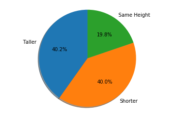

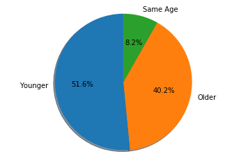

```python
import matplotlib.pyplot as plt

# Plot a pie chart of the heights to compare what heights the winners had
labels = 'Taller', 'Shorter', 'Same Height'
height_totals = [taller_total, shorter_total, same_height]
# Heights as percentages to be used for the pie chart
heights = [((x / np.sum(height_totals)) * 100) for x in height_totals]

fig1, ax1 = plt.subplots()
ax1.pie(heights, labels=labels, autopct='%1.1f%%',
        shadow=True, startangle=90)

# Equal aspect ratio ensures that pie is drawn as a circle.
ax1.axis('equal')

plt.show()

# Plot a pie chart of the heights to compare what age the winners were.
labels = 'Younger', 'Older', 'Same Age'
age_totals = [younger_total, older_total, same_age]
# Heights as percentages to be used for the pie chart
ages = [((x / np.sum(age_totals)) * 100) for x in age_totals]

fig2, ax2 = plt.subplots()
ax2.pie(ages, labels=labels, autopct='%1.1f%%',
        shadow=True, startangle=90)

# Equal aspect ratio ensures that pie is drawn as a circle.
ax2.axis('equal')

plt.show()
```